# Problem set 0 — Setting Up Your Data Science Computer Environment

Author

Affiliation

Adam Altmejd Selder

Swedish Institute for Social Research (SOFI)

Published

April 14, 2025

# Introduction

This is a guide for you to prepare your data science environment. The idea is that you go through these instructions between Lectures 1 and 2. That way, you will be able to follow along on your own computer in the classroom. And if there are any issues, we can sort them out before the real first problem set.

This guide provides step-by-step instructions on how to install R (with RStudio), Python, Julia, and Stata. We will primarily use R in class, and you can complete this course without installing any of the other interpteters, but I encourage you to explore different languages throughout the class. This document also covers setting up the version control system Git and creating an account on GitHub.com, installing my favorite code editor (Visual Studio Code), configuring SSH keys for GitHub, and creating your first GitHub repository.

The instructions are organized by operating system.

**Windows users** have two options: (1) Use the instructions under the “Windows” labels (recommended), or (2) install a Debian-based (e.g., Ubuntu) Linux distribution using Windows Subsystem for Linux (WSL) and follow the “Linux” instructions (advanced).

For **Mac users**, I highly recommend installing the **Homebrew package manager** by following the instructions on [brew.sh](https://brew.sh/). This will make everything really easy. If you prefer not to, I have provided alternative instructions as well.

If you use **Linux**, you likely already have many of these tools installed. Note that the instructions here are for Debian-based systems like Ubuntu. If you are on a different system and have any questions, let me know.

Whenever there are code blocks in the instructions:

```bash
echo "hej"
```

it means you need to type the command in your terminal. **NB:** The Windows command prompt and Powershell often have a different syntax than the Mac/Linux terminal. By using the “Git Bash” application that comes with Git on Windows (instructions below), also Windows users can use the same syntax.

To launch a terminal start the Git Bash application on Windows, on Mac, you can find the built-in Terminal app under `Applications/Utilities/Terminal`. The terminal window should look something like this (on Mac, if you haven’t changed anything):

[figure not shown]

## Error!? But I did exactly as you said…

There are lots of reasons why these instructions might not work for you. If you have problems with R or Git specifically, https://happygitwithr.com is a great resource. Many problems have been answered on Stack Overflow, and can be found by googling (try googling the error message). You can also ask your favorite LLM Chatbot for help (try pasting the error message), discuss in class, or send me an email.

# Tools used in class

## R

**Windows**

Go to the [CRAN website](https://cran.r-project.org) and click **Download R for Windows**. On the Windows download page, click the **base** download link to get the latest R installer. Run the installer and follow the prompts (you can accept the default settings) to install R.

The installer will install a basic R GUI app (and place a shortcut on your desktop). We will not be using this app to run R later, but you can start it now to verify the installation worked. It should look something like this:

[figure not shown]

**macOS**

**Option 1 (recommended):**

Using the package manager Homebrew ([install Homebrew first](https://brew.sh/)), run the following command in your Terminal:

```bash
brew install --cask r
```

**Option 2 (manual install):**

Go to the [CRAN website](https://cran.r-project.org) and click **Download R for macOS**. Download the latest `.pkg` installer for R. Once downloaded, double-click the `.pkg` file and follow the installer prompts.

Some R packages require X11 for creating graphics. You can download and install it [here](https://www.xquartz.org/index.html), or install using brew:

```bash
brew install --cask xquartz
```

**Linux**

```bash
sudo apt update
sudo apt install r-base
```

## VS Code

Next, we are going to install an integrated development environment (IDE) for writing code. IDEs are enhanced text editors with many extra features. You may have tried the Stata do-file editor or RStudio before. I prefer VS Code and encourage you to try it. In class, we’ll see how to use VS Code to connect to servers, access the terminal, create plots, browse data, and more. You can do powerful things like find and replace across multiple files or edit several rows of text at once. Best of all you can access the GitHub Copilot AI assistant for free, right inside VS Code. And if you register for Github Education you even get access to the pro version free of charge. Under additional software you will find instructions for installing alternative IDEs.

**Windows**

Download and install VS Code from [VS Code’s download page](https://code.visualstudio.com/download). Keep the default options throughout the install, but I suggest also select to configure the “Open with Code” context menus. That way you can right click on a folder to open it directly in VS Code.

By default, VS Code will use Powershell for the integrated terminal. You probably wan to change this to Git Bash. Do so by pressing Ctrl+Shift+P and start writing *Select default profile*, press enter and use the arrow keys to chose *Git Bash*.

**macOS**

**Homebrew (recommended)**

```bash
brew install --cask visual-studio-code
```

**Manual install**

Download [VS Code](https://code.visualstudio.com/download), extract the archive, and move the app into the Applications folder.

**Linux**

Follow the [official instructions](https://code.visualstudio.com/docs/setup/linux#_install-vs-code-on-linux) to download the `.deb` file and install by running:

```bash
sudo apt install ./<file>.deb
```

### VS Code R extension

To get VS Code working more like RStudio you need the [VS Code R extension](https://marketplace.visualstudio.com/items?itemName=REditorSupport.r). With VS Code open go to **Extensions** in the sidebar, either by clicking, using the shortcut Ctrl/Cmd+Shift+X, or from the universal shortcut Ctrl/Cmd+Shift+P and then start writing *install extensions*. At the top of the extension pane, enter *R* in the *Search Extensions in Marketplace* input box then click *Install extension*. You can also install it from [here](https://marketplace.visualstudio.com/items?itemName=REditorSupport.r).

[figure not shown]

After having installed the extension, you will also need to install two R packages to get everything working. Easiest way to do so is to open an R terminal in VS Code using the shortcut Ctrl/Cmd+Shift+P and picking *Create R Terminal*. In the R terminal window write the command below and press enter. This should install the `languageserver`, which is used by R to talk to VS Code and provide e.g., help about functions. `httpgd` is used to show the plots you make inside VS Code.

Run this from an **R terminal** to install packages:

```r
install.packages(c("languageserver", "httpgd"))
```

[figure not shown]

Here is a [nice introduction](https://code.visualstudio.com/docs/languages/r) to using R in VS Code.

### VS Code R debugger (optional)

You can also get the great debugging features that are available in R Studio into VS Code using the [VS Code R debugger extension](https://marketplace.visualstudio.com/items?itemName=RDebugger.r-debugger). Similarly to the VS Code R extension, it relies on an R package ([documentation](https://manuelhentschel.github.io/vscDebugger/)) that you will also need to install.

```r
# Run from an R terminal
install.packages("vscDebugger")
```

The extension is still in active development and in my experience has been quite buggy. But it might already be working much better since when I last used it!

## Git and GitHub

Git is a **version control system** for tracking changes in your code, especially useful when collaborating with others. We will spend much of lecture 2 talking about it. [GitHub](https://github.com/) is a platform for hosting Git repositories.

**Windows**

1. **Download Git:** Go to [Git for Windows](https://git-scm.com/download/win) and download the installer.
2. **Install Git:** Run the installer. Accept defaults, and select Visual Studio Code as the default editor. Important: chose the recommended PATH adjustment, “Git from the command line and also from 3rd-party software”. The installer will install the Git Bash application, which functions as a Linux-style command prompt on Windows.
3. **Verify the installation:** Open **Git Bash** and run:

   ```bash
   git --version
   ```

   It should look like this:

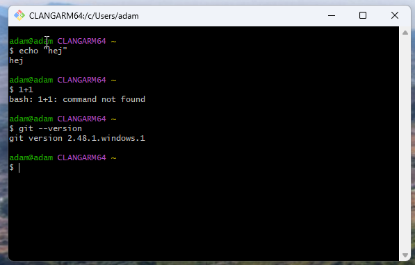

**macOS**

- **Option 1:** Use Homebrew:

  ```bash
  brew install git
  ```

- **Option 2:** Use the version of Git bundled with Apple developer tools (Xcode) by installing the Xcode command line tools:

  ```bash
  xcode-select --install
  ```

**Linux**

```bash
sudo apt update
sudo apt install git
```

No matter what platform you are on, after installing Git, open your terminal (Git Bash on Windows) and set up your Git profile. If you typed the command correctly, you will not get any confirmation after you pressed Enter.

```bash
git config --global user.name "Your Name"
git config --global user.email "youremail@example.com"
```

### Registering for GitHub and GitHub Education

Next, go to [GitHub.com](https://github.com/) to register an account (if you don’t already have one). Use the same email you set in your Git config. After registering and verifying your account, visit https://github.com/education/students to sign up for GitHub Education. You will need to enter an SU email address (and link it to your account). This should be enough to get verified. Once you are registered and verified, try the Copilot Chat in VS Code again. You should have access to more advanced models like Claude 3.7.

## SSH

SSH is short for “secure shell”. It is a program used to connect to servers in a secure (encrypted) manner. SSH uses *public key cryptography* where a pair of keys is needed to communicate securely. One key in the pair is called the **private key**. This key should be kept secure and never shared with anyone. The second part is the **public key**. You share this part with the servers and services you want to communicate with. When connecting, SSH then uses the private key (stored on your computer only) to encrypt a message that can be verified with the public key. Even though the server does not have access to the private key, it knows that only the holder of that key can have sent the message.

### Generating a key pair

```bash
ssh-keygen -t ed25519 -C "your_email@example.com"
```

Press Enter to accept the default file location. When prompted, enter a passphrase/password (your terminal will not show characters as you type). I recommend you pick a 5-6 words long passphrase (for example from here https://strongphrase.net/) and to store it in a password manager (or write it down on paper).

SSH will place the keypair in two files, the public key gets the file ending `.pub`. If you do not change the default location, the files are places in a folder called `.ssh` in your home folder. On Mac that is `/Users/<username>/.ssh`, on Windows, Git Bash should have created a home folder for you with the path `C:\Users\<username>` and if you ran ssh from within Git Bash it should have created an .ssh folder at `C:\Users\<username>\.ssh`.

You now have everything you need to connect to servers and use GitHub over SSH. You wil however have to enter the passphrase each time you use your key. To save the passphrase on your computer, so that you only need your computer password you can use SSH Agent. Read more in the optional section.

### Connecting to Github over SSH

To use SSH with Github you first need to add your public key to your GitHub profile, under the [“SSH and GPG keys”](https://github.com/settings/keys) settings page. There, you should see a green button saying “New SSH Key”. Click it, give your key a name (only relevant once you have many keys and want to remember which is which) then enter the public key into the text box under *Key*.

How do you access your newly created public key? If you did not change anything, the `ssh-keygen` command saved the public key inside a text file called `id_ed25519.pub` in a folder called `.ssh` located in your home folder. Because it starts with a `.`, the `.ssh` folder counts as a “system” folder and is hidden. Easiest way to access it is from a Shell Terminal. You can try the following shell command to automatically copy the key to you clipboard:

```bash
pbcopy < ~/.ssh/id_ed25519.pub
```

If it works, simply paste the key into the GitHub text box with Ctrl/Cmd+V. But some computers will not support `pbcopy`. An alternative is to open a terminal and run `explorer ~/.ssh` on Windows or `open ~/.ssh` on Mac to open the `.ssh` folder in Explorer/Finder. From there you can open the `id_ed25519.pub` file in VS Code and copy the key.

A third option is to run:

```bash
cat ~/.ssh/id_ed25519.pub
```

which will print the public key to your terminal for you to copy manually. Be careful though and make sure you copy the whole key and nothing but the key. The SSH key should look something like:

```
ssh-ed25519 AAAAC3NzaC1lZDI1NTE5AAAAINv0cIh+5va7jISfgq/cAAUJwo2OK5yTOvr4zx9CHfYp your_email@example.com
```

Finally, when you have added your key to your GitHub account and pressed save. You can test that everything works by running:

```bash
ssh -T git@github.com
> Hi adamaltmejd! You've successfully authenticated, but GitHub does not provide shell access.
```

That is what you see if everything works. If not, try to read the error message and debug. The [official documentation](https://docs.github.com/en/authentication/connecting-to-github-with-ssh/adding-a-new-ssh-key-to-your-github-account) could be helpful, or try Google. If it works, you can now clone repositories using SSH rather than https. Try it out on the course repository! We will use SSH to connect to servers in the course.

# Other useful tools to explore on your own (optional)

## Programming Language interpreters (and Stata)

This section covers installing R, Python, and Julia. Throughout the course, we will focus on R because it currently has the best (in my humble opinion) data science toolkit, though Python and Julia are close behind.

One goal of this course is to help you view programming languages (and statistical software like Stata) as tools, each with different strengths. By the end, you should feel comfortable switching between languages—or even learning new ones—when the situation calls for it. You will be able to do everything we do in class in R, but I have provided instructions for Python and Julia too if you would like to experiment with those languages on your own.

### Python

**Windows**

Python can be installed from the [Microsoft Store](https://apps.microsoft.com/detail/9nrwmjp3717k?hl=en-US&gl=US). After installation, verify it by opening Powershell and running `python`. It should look like this:

[figure not shown]

**macOS**

**Homebrew (recommended)**

```bash
brew install python
```

**Manual install**

Download the latest Python 3.x installer from [Python’s official site](https://www.python.org/downloads/macos/). Run the `.pkg` installer and follow the prompts.

**Linux**

```bash
sudo apt update
sudo apt install python3 python3-pip
```

### Julia

Julia is an up-and-coming scientific programming language with very promising functionality. It employs several modern programming paradigms and recently passed the 1.0 milestone so it should be more stable to use nowadays. Still not that commonly used in Economics, though I think it’s growing in popularity quite fast among macroeconomists, and will for sure replace Matlab sooner or later. This book is a great resource for learning how to do macro in Julia: https://julia.quantecon.org/intro.html.

**Windows**

Julia can be installed from the [Microsoft Store](https://www.microsoft.com/store/apps/9NJNWW8PVKMN). You can launch a Julia interpreter by running `julia` in Powershell or by starting the app. It should look like this when running:

[figure not shown]

**macOS**

**Homebrew (recommended)**

```bash
brew install julia
```

**Manual install**

As described on [julialang.org](https://julialang.org/downloads/), run:

```bash
curl -fsSL https://install.julialang.org | sh
```

**Linux**

As described on [julialang.org](https://julialang.org/downloads/), run:

```bash
curl -fsSL https://install.julialang.org | sh
```

### Stata

Stata is proprietary software, but still often used by Economists. You probably know some Stata from your previous courses and may be more comfortable continuing to use it for tasks it does well (such as estimation and inference). In that case you probably already have Stata installed. If you have never used Stata, I would not recommend starting now, but if you wish to do so, you can find the install instructions on the [Stockholm University website](https://www.su.se/utbildning/it-f%C3%B6r-studenter/licenser-och-program/stata-se-1.445814?open-collapse-boxes=collapseCollapsible1730983659344_861617).

## Alternative IDEs

### RStudio

RStudio is the most commonly used editor for working in R. It is great for R in particular and also data science in general, but it lacks many features and extendability when compared to VS Code. However, you might still prefer it for its easy of use with R especially.

**Windows**

**RStudio:** Download and install RStudio from the [official download page](https://posit.co/download/rstudio-desktop/). Accept the default settings during install.

**macOS**

**Homebrew (recommended)**

```bash
brew install --cask rstudio
```

**Manual install**

Download [RStudio Desktop for macOS](https://posit.co/download/rstudio-desktop/) and install by opening the `.dmg` file and dragging **RStudio** into your Applications folder.

**Linux**

Download the `.deb` package from [RStudio’s download page](https://posit.co/download/rstudio-desktop/) and run:

```bash
sudo apt install ./rstudio-*.deb
```

### Positron (in beta, optional)

Positron might be the perfect combination of VS Code and R. It is actually built upon the open-source parts of VS Code but tailored specifically to R users. If you want to try it you need to download and install it from [Posit’s website](https://positron.posit.co/).

## Adding your SSH key to the SSH agent

The passphrase gives the key additional security and will be required each time you use the key, this might become a bit annoying after a while. You achieve both security and convenience by storing the passphrase in your computer’s `ssh agent`. This way, you will just need your computer’s admin password instead. With the help of the agent, you will only have to enter it when you set up a new computer. On Mac and Linux it is simple to get the SSH agent working, but the Windows instructions are a bit more complicated unfortunately.

**Windows**

Each time you start a new Git Bash session you need to make sure that the ssh-agent is running, or else it will not be available. One way to autorun ssh-agent when Git Bash starts is to use a startup script. This is what [GitHub recommends](https://docs.github.com/en/authentication/connecting-to-github-with-ssh/working-with-ssh-key-passphrases#auto-launching-ssh-agent-on-git-for-windows). You need to edit a file called `.profile` that is located in your home directory. Each time you start a new Bash shell, bash will run this file. The easiest way to create the file is to open it in VS Code from the terminal. Open a new Git Bash window and type `code .profile` to open the file `.profile` in VS Code (and create it if it did not already exist). You will most likely see an empty file. Add the following code to the file and save:

```bash
env=~/.ssh/agent.env

agent_load_env () { test -f "$env" && . "$env" >| /dev/null ; }

agent_start () {
    (umask 077; ssh-agent >| "$env")
    . "$env" >| /dev/null ; }

agent_load_env

# agent_run_state: 0=agent running w/ key; 1=agent w/o key; 2=agent not running
agent_run_state=$(ssh-add -l >| /dev/null 2>&1; echo $?)

if [ ! "$SSH_AUTH_SOCK" ] || [ $agent_run_state = 2 ]; then
    agent_start
    ssh-add
elif [ "$SSH_AUTH_SOCK" ] && [ $agent_run_state = 1 ]; then
    ssh-add
fi

unset env
```

Now, open a new Git Bash terminal and if everything works you should not get any errors or warning messages. Then, run `ssh-add -l` to check if your keys are loaded. If the agent had not started, you will get an error.

**MacOS / Linux**

```bash
eval "$(ssh-agent -s)"
ssh-add ~/.ssh/id_ed25519
```

You can verify that the agent has access to your key by running `ssh-add -l` (`-l` for list). If you need more help, GitHub has a nice guide for how to [generate an SSH keypair](https://docs.github.com/en/authentication/connecting-to-github-with-ssh/generating-a-new-ssh-key-and-adding-it-to-the-ssh-agent).